# Algorithms

`ooacquire` 0.1.3.9000

Pedro J. Aphalo

2017-05-10

## Irradiance

We will step through the different steps of the algorithm used, plotting the spectra at each step along the way. We use raw counts data, included in the package, to make building this vignette easier. At the same time we show how raw data acquire outwith R can be also processed with the package.

## Interactive acquisition of spectral irradiance

We first load the R packages to be used.

```r
library(ggplot2)
library(ggspectra)
library(photobiology)
library(photobiologyWavebands)
library(ooacquire)
library(magrittr)
```

### Household white LED bulb

We will read data from the measurement of the irradiance under a white LED light source—*Osram LED Star classic A 60 E27*. It was measured with a Ocean Optics, Maya 2000 Pro spectrometer, using the function `acquire_irrad_interactive()`.

We calculate irradiance from a set of raw-counts spectral data using a high-level function.

```r
LED_lamp_recalc.spct <-
  s_irrad_corrected(white_LED_2min.raw_mspct,
                    correction.method= ooacquire::MAYP11278_ylianttila.mthd)
```

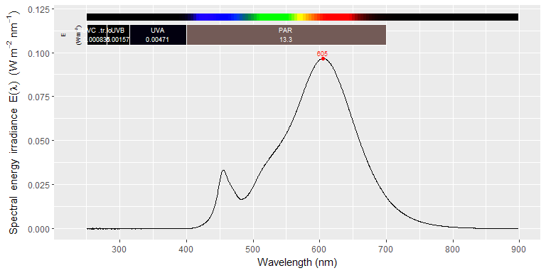

```r
plot(LED_lamp_recalc.spct)
```

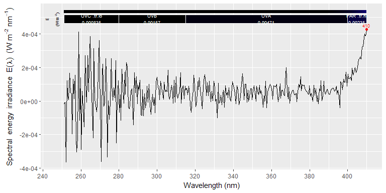

```r
plot(LED_lamp_recalc.spct, range = c(250, 410))
```

```r
white_LED.raw_mspct
```

```
## Object: raw_mspct [3 x 1]
## --- Member: light ---
## Object: raw_spct [2,068 x 3]
## Wavelength range 187.82 to 1117.14 nm, step 0.41 to 0.48 nm
## what label: light
## user.label label: osram06
## Measured on 2016-12-01 10:08:16 UTC
## Data acquired with 'MayaPro2000' s.n. MAYP11278
## grating 'HC1', slit '010s'
## integ. time (s): 0.32, 3.2
## total time (s): 5.11, 6.39
## counts @ peak (% of max): 94.3
##
## # A tibble: 2,068 × 3
##    w.length counts_1 counts_2
##       <dbl>    <dbl>    <dbl>
## 1    187.82 2302.500   2303.0
## 2    188.30 2220.688   2219.5
## 3    188.78 2190.250   2188.0
## 4    189.26 2192.938   2191.5
## 5    189.73 2593.625   6033.5
## 6    190.21 2629.500   6421.0
## 7    190.69 2645.625   6624.5
## 8    191.17 2658.125   6647.0
## 9    191.64 2690.375   6990.5
## 10   192.12 2658.312   6684.5
## # ... with 2,058 more rows
## --- Member: filter ---
## Object: raw_spct [2,068 x 3]
## Wavelength range 187.82 to 1117.14 nm, step 0.41 to 0.48 nm
## what label: filter
## user.label label: osram06
## Measured on 2016-12-01 10:08:16 UTC
## Data acquired with 'MayaPro2000' s.n. MAYP11278
## grating 'HC1', slit '010s'
## integ. time (s): 0.32, 3.2
## total time (s): 5.11, 6.39
## counts @ peak (% of max): 94.3
##
## # A tibble: 2,068 × 3
```

[output cut: 26 more lines]

```
##    w.length counts_1 counts_2
##       <dbl>    <dbl>    <dbl>
## 1    187.82 2301.062   2303.0
## 2    188.30 2218.625   2224.0
## 3    188.78 2190.000   2192.0
## 4    189.26 2192.188   2192.5
## 5    189.73 2589.750   6002.0
## 6    190.21 2624.500   6405.5
## 7    190.69 2634.500   6436.5
## 8    191.17 2634.250   6540.5
## 9    191.64 2663.062   6757.5
## 10   192.12 2637.812   6547.5
## # ... with 2,058 more rows
##
## --- END ---
```

Ploting the three bracketed spectra shows the raw data. The detector saturates at approximately 64000 counts.

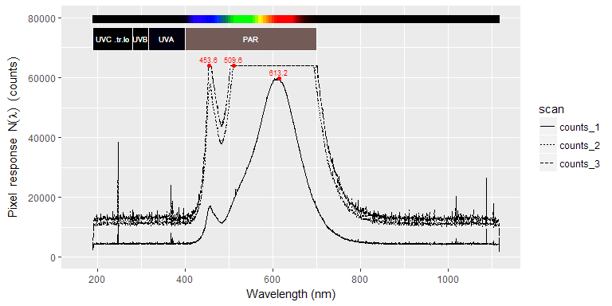

```r
plot(white_LED_2min.raw_mspct[["light"]])
```

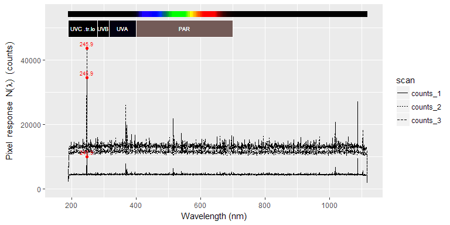

```r
plot(white_LED_2min.raw_mspct[["dark"]])
```

The first step in the processing is removal of bad pixels, as recorded in the calibration data.

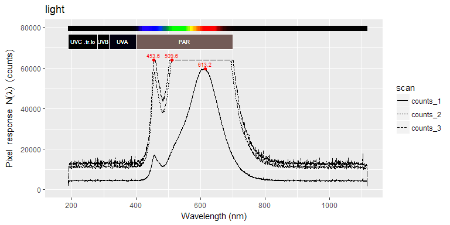

```r
for (m in names(white_LED_2min.raw_mspct)) {
  white_LED_2min.raw_mspct[[m]] <-
    skip_bad_pixs(white_LED_2min.raw_mspct[[m]])
  print(plot(white_LED_2min.raw_mspct[[m]]) + ggtitle(m))
}
```

Next step is to replace saturated pixel data, with the missing data marked `NA`.

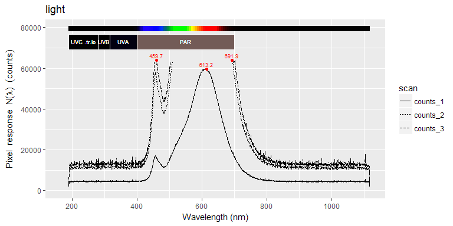

```r
for (m in names(white_LED_2min.raw_mspct)) {
  white_LED_2min.raw_mspct[[m]] <-
    trim_counts(white_LED_2min.raw_mspct[[m]])
  print(plot(white_LED_2min.raw_mspct[[m]]) + ggtitle(m))
}
```

Saturated pixels can affect the readings from nearby pixels through charge migration, so we need to also tag as `NA`s these additional pixels.

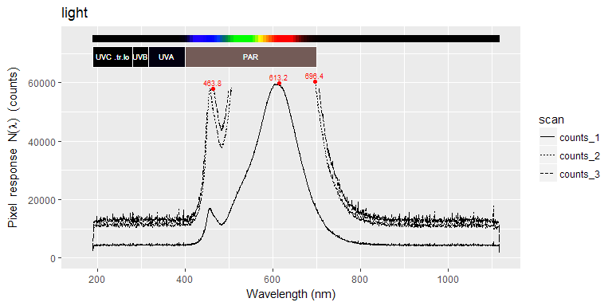

```r
for (m in names(white_LED_2min.raw_mspct)) {
  white_LED_2min.raw_mspct[[m]] <-
    bleed_nas(white_LED_2min.raw_mspct[[m]])
  print(plot(white_LED_2min.raw_mspct[[m]]) + ggtitle(m))
}
```

Next we need to apply a linearization function, as detector response is not linear—saturation is gradual.

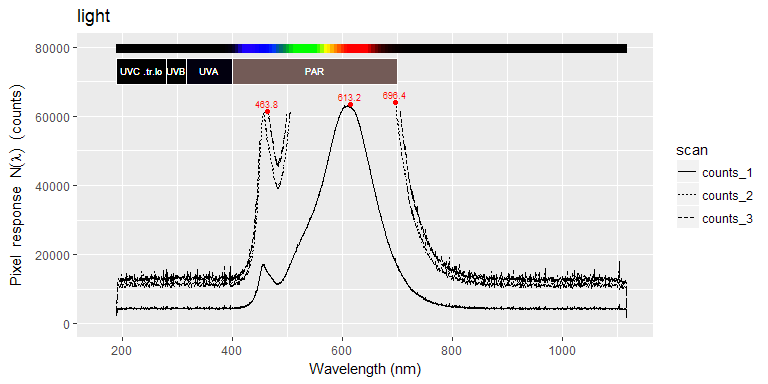

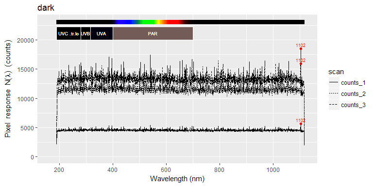

```r
for (m in names(white_LED_2min.raw_mspct)) {
  white_LED_2min.raw_mspct[[m]] <-
    linearize_counts(white_LED_2min.raw_mspct[[m]])
  print(plot(white_LED_2min.raw_mspct[[m]]) + ggtitle(m))
}
```

We may next remove an estimate of dark signal based on reference pixels not expected to be excited. This step may apear redundant, but *might* help in cases when instrument temperature is not stable.

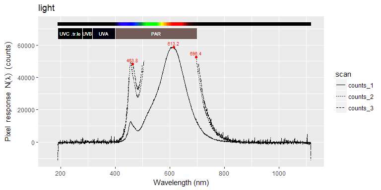

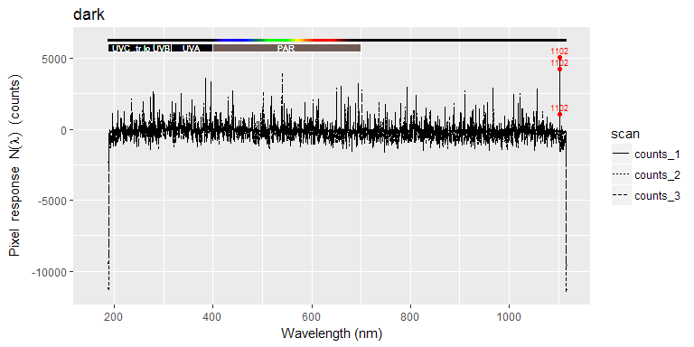

```r
for (m in names(white_LED_2min.raw_mspct)) {
  white_LED_2min.raw_mspct[[m]] <-
    fshift(white_LED_2min.raw_mspct[[m]], range = c(250,290))
  print(plot(white_LED_2min.raw_mspct[[m]]) + ggtitle(m))
}
```

Now we can convert the raw counts into counts per second.

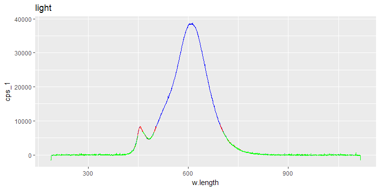

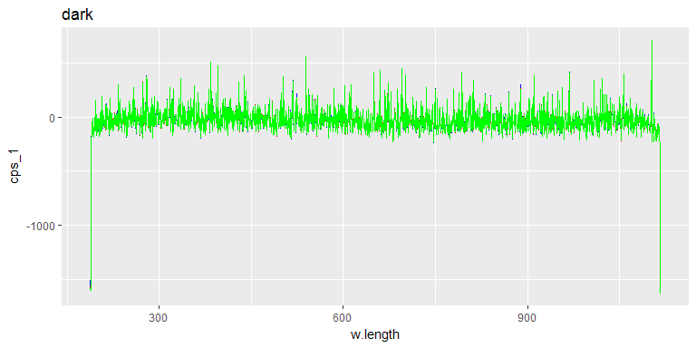

```r
white_LED_2min.cps_mspct <- cps_mspct()
for (m in names(white_LED_2min.raw_mspct)) {
  white_LED_2min.cps_mspct[[m]] <-
    raw2cps(white_LED_2min.raw_mspct[[m]])
  print(
    ggplot(white_LED_2min.cps_mspct[[m]], aes(x = w.length)) +
      geom_line(aes(y = cps_1), color = "blue") +
      geom_line(aes(y = cps_2), color = "red") +
      geom_line(aes(y = cps_3), color = "green") +
      ggtitle(m)
  )
}
```

Next splicing of the bracketed integrations.

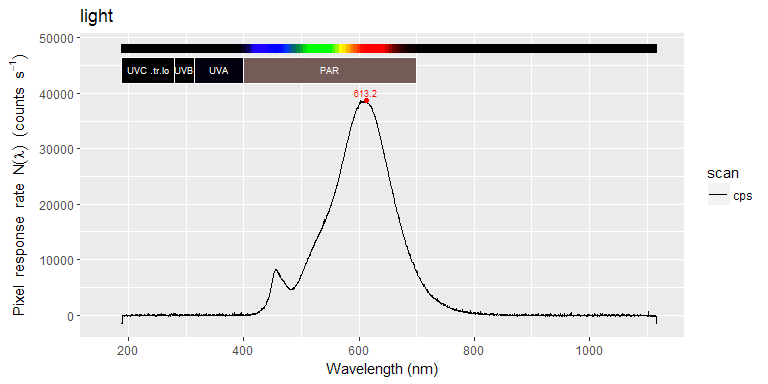

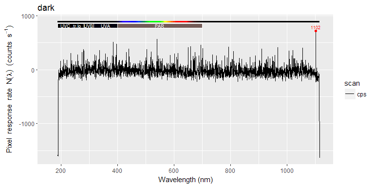

```r
for (m in names(white_LED_2min.cps_mspct)) {
  white_LED_2min.cps_mspct[[m]] <-
    merge_cps(white_LED_2min.cps_mspct[[m]])
  print(plot(white_LED_2min.cps_mspct[[m]]) + ggtitle(m))
}
```

We now subtract the dark signal from the light measurement.

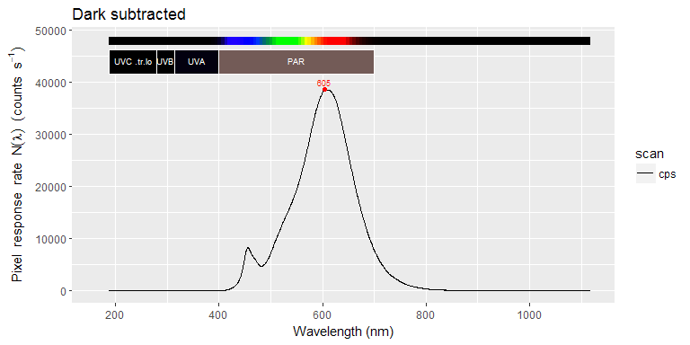

```r
white_LED_2min.cps_spct <-
  white_LED_2min.cps_mspct[["light"]] - white_LED_2min.cps_mspct[["dark"]]
white_LED_2min.cps_spct <-
  copy_attributes(white_LED_2min.raw_mspct[["light"]],
                  white_LED_2min.cps_spct,
                  copy.class = FALSE)
plot(white_LED_2min.cps_spct) + ggtitle("Dark subtracted")
```

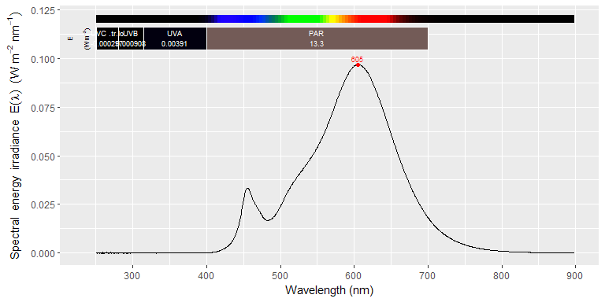

```r
white_LED_2min.spct <- cps2irrad(white_LED_2min.cps_spct)
plot(white_LED_2min.spct)
```

We can finally smooth-out some of the noise.

```r
white_LED_2min.spct <- smooth_spct(white_LED_2min.spct)
```

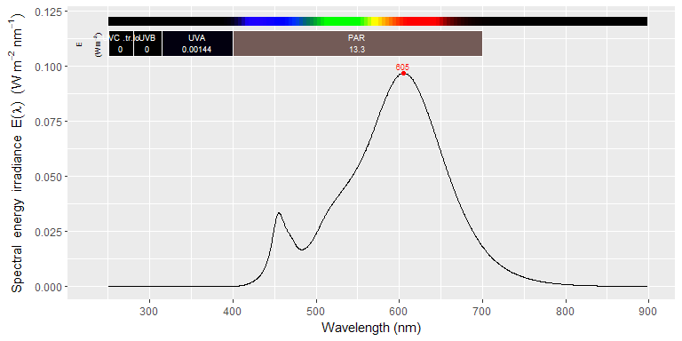

```r
plot(white_LED_2min.spct)
```

With an LED source, at least in the case of our Maya 2000 Pro, we do not need to worry about stray light. However, when we measure light sources with a significant emission in the infra-red above 1000 nm, stray light becomes a problem. In addition sources with narrow peaks of emission may benefit from deconvolution of a measured slit function.

### Tungsten halogen lamp

We calculate irradiance from a set of raw-counts spectral data using a high-level function.

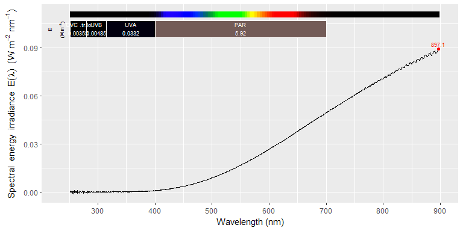

```r
halogen.spct <-
  s_irrad_corrected(halogen.raw_mspct, correction.method= MAYP11278_ylianttila.mthd)
plot(halogen.spct)
```

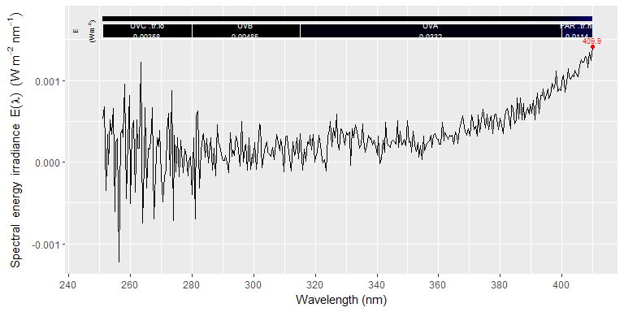

```r
plot(halogen.spct, range = c(250, 410))
```

```r
halogen.raw_mspct
```

```
## Object: raw_mspct [3 x 1]
## --- Member: light ---
## Object: raw_spct [2,068 x 3]
## Wavelength range 187.82 to 1117.14 nm, step 0.41 to 0.48 nm
## Label: Halogen
## Measured on 2017-03-28 11:24:35 UTC
## Data acquired with 'MayaPro2000' s.n. MAYP11278
## grating 'HC1', slit '010s'
## integ. time (s): 1.86, 7.2
## total time (s): 5.58, 7.2
## counts @ peak (% of max): 94.4
##
## # A tibble: 2,068 × 3
##    w.length counts_1 counts_2
##       <dbl>    <dbl>    <dbl>
## 1    187.82 2288.333     2285
## 2    188.30 2210.000     2211
## 3    188.78 2182.333     2180
## 4    189.26 2181.667     2184
## 5    189.73 3865.000     8578
## 6    190.21 4119.667     9494
## 7    190.69 4114.000     9675
## 8    191.17 4178.667     9918
## 9    191.64 4310.000    10366
## 10   192.12 4189.667     9875
## # ... with 2,058 more rows
## --- Member: filter ---
## Object: raw_spct [2,068 x 3]
## Wavelength range 187.82 to 1117.14 nm, step 0.41 to 0.48 nm
## Label: Halogen
## Measured on 2017-03-28 11:25:54 UTC
## Data acquired with 'MayaPro2000' s.n. MAYP11278
## grating 'HC1', slit '010s'
## integ. time (s): 1.86, 7.2
## total time (s): 5.58, 7.2
## counts @ peak (% of max): 94.4
##
## # A tibble: 2,068 × 3
##    w.length counts_1 counts_2
##       <dbl>    <dbl>    <dbl>
```

[output cut: 23 more lines]

```
##    w.length counts_1 counts_2
##       <dbl>    <dbl>    <dbl>
## 1    187.82 2287.667     2290
## 2    188.30 2211.667     2209
## 3    188.78 2182.667     2185
## 4    189.26 2182.667     2183
## 5    189.73 3816.000     8408
## 6    190.21 4053.667     9346
## 7    190.69 4000.333     9231
## 8    191.17 4062.000     9404
## 9    191.64 4179.667     9863
## 10   192.12 4053.000     9350
## # ... with 2,058 more rows
##
## --- END ---
```

We first use a “pipe” to apply the same initial processing steps as for the LED bulb data in the previous section.

```r
halogen.cps_mspct <- cps_mspct()
for (m in names(halogen.raw_mspct)) {
  halogen.raw_mspct[[m]] %>%
    skip_bad_pixs() %>%
    trim_counts() %>%
    bleed_nas() %>%
    linearize_counts() %>%
    fshift(range = c(187.82,189.26)) %>%
    raw2cps() %>%
    merge_cps() -> halogen.cps_mspct[[m]]
}
halogen.cps_mspct
```

```
## Object: cps_mspct [3 x 1]
## --- Member: light ---
## Object: cps_spct [2,068 x 2]
## Wavelength range 187.82 to 1117.14 nm, step 0.41 to 0.48 nm
## Label: Halogen
## Measured on 2017-03-28 11:24:35 UTC
## Data acquired with 'MayaPro2000' s.n. MAYP11278
## grating 'HC1', slit '010s'
## integ. time (s): 1.86, 7.2
## total time (s): 5.58, 7.2
## counts @ peak (% of max): 94.4
##
## # A tibble: 2,068 × 2
##    w.length          cps
##       <dbl>        <dbl>
## 1    187.82   10.6009359
## 2    188.30    0.3464329
## 3    188.78   -3.9493661
## 4    189.26   -3.3950696
## 5    189.73  884.2018178
## 6    190.21 1011.9826105
## 7    190.69 1037.2621437
## 8    191.17 1071.2176472
## 9    191.64 1133.8706633
## 10   192.12 1065.2076455
## # ... with 2,058 more rows
## --- Member: filter ---
## Object: cps_spct [2,068 x 2]
## Wavelength range 187.82 to 1117.14 nm, step 0.41 to 0.48 nm
## Label: Halogen
## Measured on 2017-03-28 11:25:54 UTC
## Data acquired with 'MayaPro2000' s.n. MAYP11278
## grating 'HC1', slit '010s'
## integ. time (s): 1.86, 7.2
## total time (s): 5.58, 7.2
## counts @ peak (% of max): 94.4
##
## # A tibble: 2,068 × 2
##    w.length          cps
##       <dbl>        <dbl>
```

[output cut: 23 more lines]

```
##    w.length          cps
##       <dbl>        <dbl>
## 1    187.82   11.0628515
## 2    188.30   -0.1616727
## 3    188.78   -3.4874526
## 4    189.26   -3.7646009
## 5    189.73  860.2825093
## 6    190.21  991.0887877
## 7    190.69  975.0378660
## 8    191.17  999.1855825
## 9    191.64 1063.2995879
## 10   192.12  991.6471539
## # ... with 2,058 more rows
##
## --- END ---
```

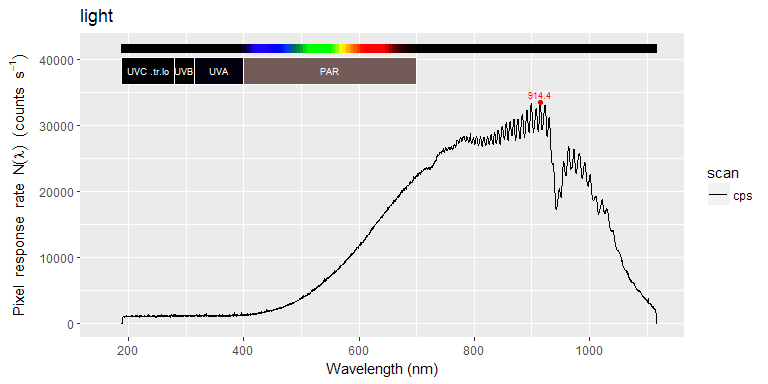

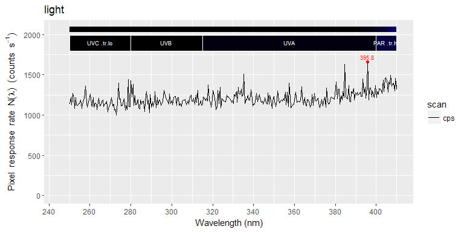

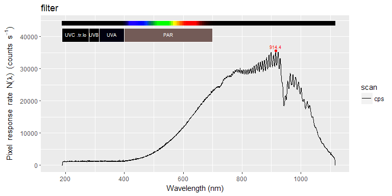

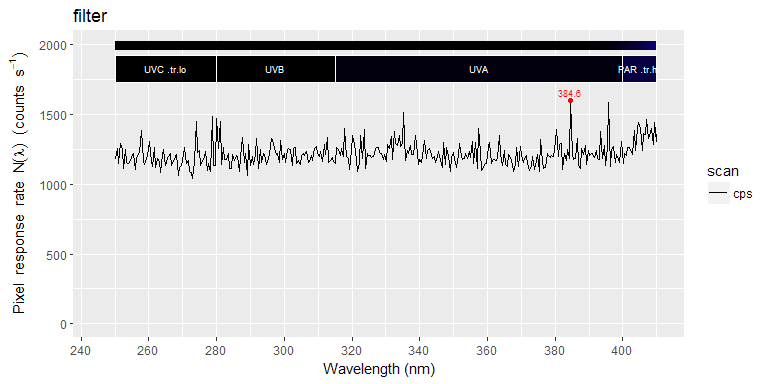

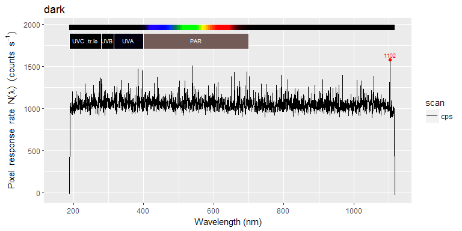

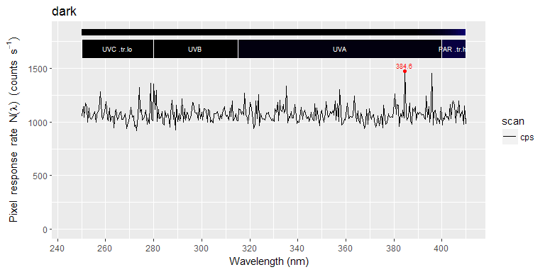

```r
for (m in names(halogen.cps_mspct)) {
  print(plot(halogen.cps_mspct[[m]]) + ggtitle(m))
  print(plot(halogen.cps_mspct[[m]], range = c(250, 410)) + ggtitle(m))
}
```

We substract the dark reading from both the light and filter measurements, and copy attributes, including instrument settings and calibration data.

```r
halogen01.cps_mspct <- cps_mspct()
for (m in setdiff(names(halogen.cps_mspct), "dark")) {
  halogen01.cps_mspct[[m]] <- halogen.cps_mspct[[m]] - halogen.cps_mspct[["dark"]]
  halogen01.cps_mspct[[m]] <-
    copy_attributes(halogen.cps_mspct[[m]],
                    halogen01.cps_mspct[[m]],
                    copy.class = FALSE)
}
halogen01.cps_mspct
```

```
## Object: cps_mspct [2 x 1]
## --- Member: light ---
## Object: cps_spct [2,068 x 2]
## Wavelength range 187.82 to 1117.14 nm, step 0.41 to 0.48 nm
## Label: Halogen
## Measured on 2017-03-28 11:24:35 UTC
## Data acquired with 'MayaPro2000' s.n. MAYP11278
## grating 'HC1', slit '010s'
## integ. time (s): 1.86, 7.2
## total time (s): 5.58, 7.2
## counts @ peak (% of max): 94.4
##
## # A tibble: 2,068 × 2
##    w.length        cps
##       <dbl>      <dbl>
## 1    187.82 -0.4619156
## 2    188.30  0.5081056
## 3    188.78 -0.4619134
## 4    189.26  0.3695313
## 5    189.73 23.9193085
## 6    190.21 20.8938227
## 7    190.69 62.2242777
## 8    191.17 72.0320647
## 9    191.64 70.5710754
## 10   192.12 73.5604916
## # ... with 2,058 more rows
## --- Member: filter ---
## Object: cps_spct [2,068 x 2]
## Wavelength range 187.82 to 1117.14 nm, step 0.41 to 0.48 nm
## Label: Halogen
## Measured on 2017-03-28 11:25:54 UTC
## Data acquired with 'MayaPro2000' s.n. MAYP11278
## grating 'HC1', slit '010s'
## integ. time (s): 1.86, 7.2
## total time (s): 5.58, 7.2
## counts @ peak (% of max): 94.4
##
## # A tibble: 2,068 × 2
##    w.length         cps
##       <dbl>       <dbl>
## 1    187.82  -0.1154786
## 2    188.30   0.4388183
## 3    188.78  -0.5312009
## 4    189.26   0.3002438
## 5    189.73  39.6018386
## 6    190.21  54.2091993
## 7    190.69  87.8667313
## 8    191.17 102.7238688
## 9    191.64  95.6973017
## 10   192.12 109.5630543
## # ... with 2,058 more rows
##
## --- END ---
```

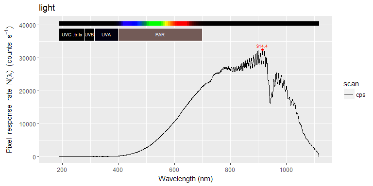

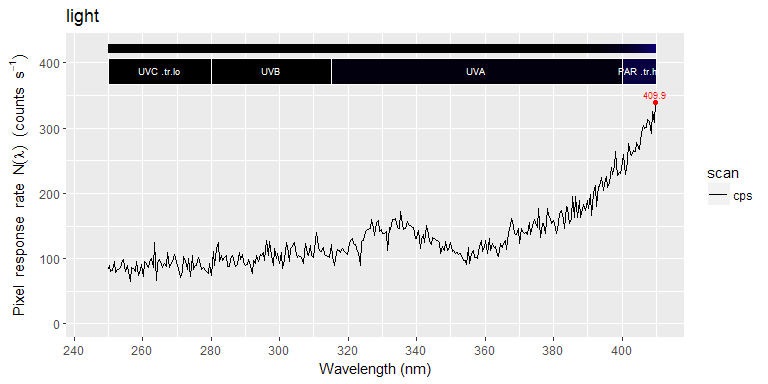

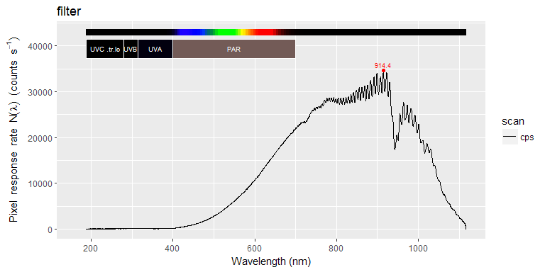

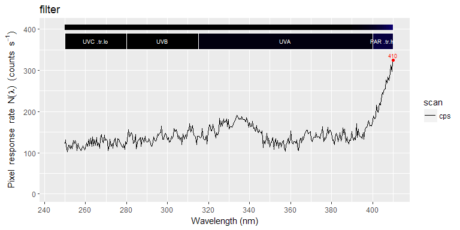

```r
for (m in names(halogen01.cps_mspct)) {
  print(plot(halogen01.cps_mspct[[m]]) + ggtitle(m))
  print(plot(halogen01.cps_mspct[[m]], range = c(250, 410)) + ggtitle(m))
}
```

As we can see in the plots above, a small amount of stray light is present in both spectra in the UV region. We apply a filter correction using a simple method based on a fixed transmittance value. By trial an error a flt.Tfr value > 1 gives best correction, which is odd…

```r
halogen_corrected.cps_spct <-
  filter_correction(halogen01.cps_mspct[["light"]],
                    halogen01.cps_mspct[["filter"]],
                    stray.light.method = "original",
                    flt.Tfr = 1.4)
```

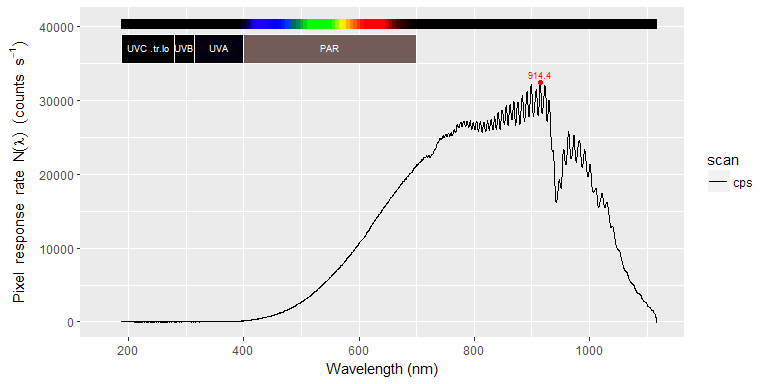

```r
plot(halogen_corrected.cps_spct)
```

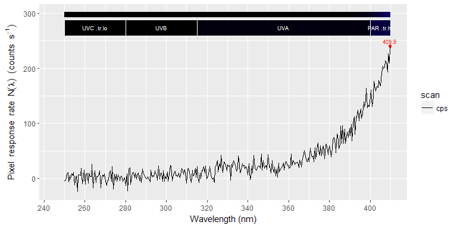

```r
plot(halogen_corrected.cps_spct, range = c(250, 410))
```

```r
mean(clip_wl(halogen_corrected.cps_spct, range = c(250, 300))[["cps"]])
```

```
## [1] 2.747068
```

```r
cps2irrad(halogen_corrected.cps_spct) -> halogen.source_spct
```

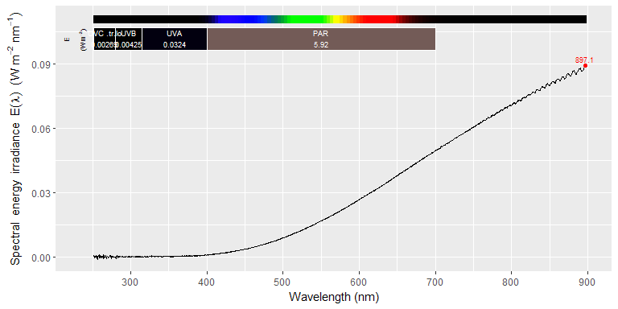

```r
plot(halogen.source_spct)
```

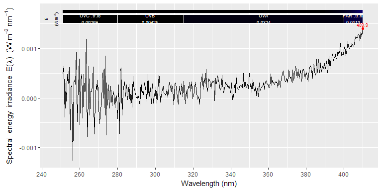

```r
plot(halogen.source_spct, range = c(250, 410))
```

```r
q_ratio(halogen.source_spct, list(UVC(), UVB(), UVA()), PAR()) * 1e3
```

```
##  UVC.ISO.tr.lo: PAR(q:q)        UVB.ISO: PAR(q:q)        UVA.ISO: PAR(q:q)
##                0.1925562                0.3494061                3.2901570
## attr(,"radiation.unit")
## [1] "q:q ratio"
```

```r
cps2irrad(halogen_corrected.cps_spct) %>%
  smooth_spct(method = "supsmu", strength = 3) -> halogen.source_spct
```

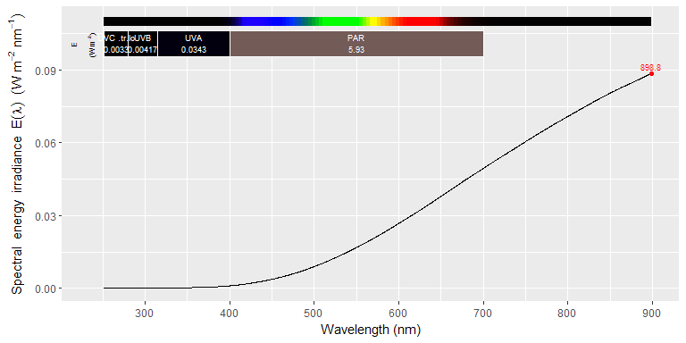

```r
plot(halogen.source_spct)
```

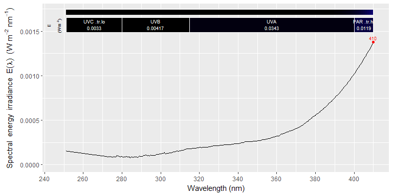

```r
plot(halogen.source_spct, range = c(250, 410))
```

```r
q_ratio(halogen.source_spct, list(UVC(), UVB(), UVA()), PAR()) * 1e3
```

```
##  UVC.ISO.tr.lo: PAR(q:q)        UVB.ISO: PAR(q:q)        UVA.ISO: PAR(q:q)
##                0.2395183                0.3434062                3.4877545
## attr(,"radiation.unit")
## [1] "q:q ratio"
```

## Coming soon

Step by step application of slit fucntion tail correction.